# Practical Machine Learning Assignment

Stefan Nickels

June 2016

# 1 Introduction

The task is to predict the quality of barbell lifts based on tracking device data from six young health participants. The categories to predict are the following:

- exactly according to the specification (A)
- throwing the elbows to the front (B)
- lifting the dumbbell only halfway (C)
- lowering the dumbbell only halfway (D)
- throwing the hips to the front (E)

For more details, please refer to http://groupware.les.inf.puc-rio.br/har#ixzz4962NQyaS

# 2 Methods

For practical reasons, I excluded all variables with a missing proportion above 95%. I will consider the imputation of missing values as an alternative approach only if the model performance turns out to be low. I further checked the variability of the variables and excluded non-informative variables, i.e. with a variability near zero. Although I was not able to clarify the meaning of all variables, I decided to include all of them. Especially the timestamp and window variables are cryptic, and I decided to keep them even if their variability will turn out to be low, because they might be important.

I centered and scaled all continuous variables.

I used the random forest approach because of its robustness, flexibility and performance.

To avoid overfittung and to estimate the out of sample error I used 10 fold cross validation (3 repetitions). I used the accuracy as a metric to judge the model performance. I aimed to reach an accuracy of 0.99.

I used the following R version and R packages:

```r
R.version.string
```

```
## [1] "R version 3.3.0 (2016-05-03)"
```

```r
library("caret")
library("e1071")
library("randomForest")
```

## 2.1 Data preparation

### 2.1.1 Load data

```r
training <- read.csv("data/pml-training.csv",
                  na.strings = c("", "NA", "#DIV/0!"),
                  stringsAsFactors = TRUE)

testing <- read.csv("data/pml-testing.csv",
                 na.strings = c("", "NA"),
                 stringsAsFactors = TRUE)
```

### 2.1.2 Check and prepare data

```r
dim(training)
```

```
## [1] 19622   160
```

```r
# proportion of missings
table(round(colSums(is.na(training))/nrow(training)*100))
```

```
##
##   0  98 100
##  60  94   6
```

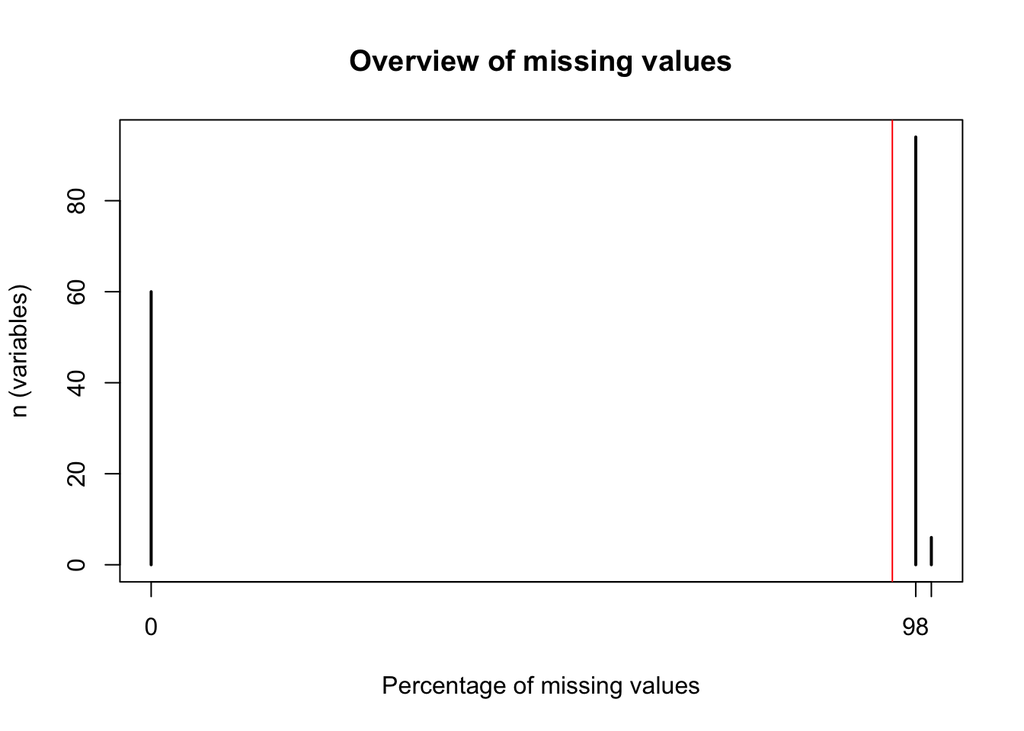

```r
plot(table(round(colSums(is.na(training))/nrow(training)*100)),
     main = "Overview of missing values",
     xlab = "Percentage of missing values",
     ylab = "n (variables)")

abline (v=95, col = "red")
```

```r
# delete columns with missings >95
training <- training[ , colSums(is.na(training)) < 0.95]
# delete row name column
# http://stackoverflow.com/questions/36110486/unable-to-delete-columns-in-r

drops <- c('X')
training <- training[ , !(names(training) %in% drops)]

# check for non-informative variables
nsr <- nearZeroVar(training, saveMetrics = TRUE)

print(nsr)
```

```
##                      freqRatio percentUnique zeroVar   nzv
## user_name             1.100679    0.03057792   FALSE FALSE
## raw_timestamp_part_1  1.000000    4.26562022   FALSE FALSE
## raw_timestamp_part_2  1.000000   85.53154622   FALSE FALSE
## cvtd_timestamp        1.000668    0.10192641   FALSE FALSE
## new_window           47.330049    0.01019264   FALSE  TRUE
## num_window            1.000000    4.37264295   FALSE FALSE
## roll_belt             1.101904    6.77810621   FALSE FALSE
## pitch_belt            1.036082    9.37722964   FALSE FALSE
## yaw_belt              1.058480    9.97349913   FALSE FALSE
## total_accel_belt      1.063160    0.14779329   FALSE FALSE
## gyros_belt_x          1.058651    0.71348486   FALSE FALSE
## gyros_belt_y          1.144000    0.35164611   FALSE FALSE
## gyros_belt_z          1.066214    0.86127816   FALSE FALSE
## accel_belt_x          1.055412    0.83579655   FALSE FALSE
## accel_belt_y          1.113725    0.72877383   FALSE FALSE
## accel_belt_z          1.078767    1.52379982   FALSE FALSE
## magnet_belt_x         1.090141    1.66649679   FALSE FALSE
## magnet_belt_y         1.099688    1.51870350   FALSE FALSE
## magnet_belt_z         1.006369    2.32901845   FALSE FALSE
## roll_arm             52.338462   13.52563449   FALSE FALSE
## pitch_arm            87.256410   15.73234125   FALSE FALSE
## yaw_arm              33.029126   14.65701763   FALSE FALSE
## total_accel_arm       1.024526    0.33635715   FALSE FALSE
## gyros_arm_x           1.015504    3.27693405   FALSE FALSE
## gyros_arm_y           1.454369    1.91621649   FALSE FALSE
## gyros_arm_z           1.110687    1.26388747   FALSE FALSE
## accel_arm_x           1.017341    3.95984099   FALSE FALSE
## accel_arm_y           1.140187    2.73672409   FALSE FALSE
## accel_arm_z           1.128000    4.03628580   FALSE FALSE
## magnet_arm_x          1.000000    6.82397309   FALSE FALSE
## magnet_arm_y          1.056818    4.44399144   FALSE FALSE
## magnet_arm_z          1.036364    6.44684538   FALSE FALSE
## roll_dumbbell         1.022388   84.20650290   FALSE FALSE
## pitch_dumbbell        2.277372   81.74498012   FALSE FALSE
## yaw_dumbbell          1.132231   83.48282540   FALSE FALSE
## total_accel_dumbbell  1.072634    0.21914178   FALSE FALSE
## gyros_dumbbell_x      1.003268    1.22821323   FALSE FALSE
## gyros_dumbbell_y      1.264957    1.41677709   FALSE FALSE
## gyros_dumbbell_z      1.060100    1.04984201   FALSE FALSE
## accel_dumbbell_x      1.018018    2.16593619   FALSE FALSE
## accel_dumbbell_y      1.053061    2.37488533   FALSE FALSE
## accel_dumbbell_z      1.133333    2.08949139   FALSE FALSE
## magnet_dumbbell_x     1.098266    5.74864948   FALSE FALSE
## magnet_dumbbell_y     1.197740    4.30129447   FALSE FALSE
## magnet_dumbbell_z     1.020833    3.44511263   FALSE FALSE
## roll_forearm         11.589286   11.08959331   FALSE FALSE
## pitch_forearm        65.983051   14.85577413   FALSE FALSE
## yaw_forearm          15.322835   10.14677403   FALSE FALSE
## total_accel_forearm   1.128928    0.35674243   FALSE FALSE
## gyros_forearm_x       1.059273    1.51870350   FALSE FALSE
## gyros_forearm_y       1.036554    3.77637346   FALSE FALSE
## gyros_forearm_z       1.122917    1.56457038   FALSE FALSE
## accel_forearm_x       1.126437    4.04647844   FALSE FALSE
## accel_forearm_y       1.059406    5.11160942   FALSE FALSE
## accel_forearm_z       1.006250    2.95586586   FALSE FALSE
## magnet_forearm_x      1.012346    7.76679238   FALSE FALSE
## magnet_forearm_y      1.246914    9.54031189   FALSE FALSE
## magnet_forearm_z      1.000000    8.57710733   FALSE FALSE
## classe                1.469581    0.02548160   FALSE FALSE
```

```r
table(training$classe)
```

```
##
##    A    B    C    D    E
## 5580 3797 3422 3216 3607
```

```r
dim(training)
```

```
## [1] 19622    59
```

Of all 5 outcomes, outcome A occurred more frequently (n about 5500) than the others (n about 3500), but this should be ok for training the model. The raw data consisted of 160 variables of 19622 observations. After quality control, 59 variables are left to train the model.

### 2.1.3 Building the prediction model

I used the training parameters as described in the methods section.

```r
set.seed(12345) # for ensuring reproducibility

#proofofprinciple
trainingsample <- training[sample(1:nrow(training), 300,
                            replace=FALSE), ]

ctrl <- trainControl(method = "repeatedcv",
                      repeats = 3,
                      classProbs = TRUE)

trainedmodel <- train(classe ~., data = trainingsample,
                      preProcess=c("center", "scale"),
                      method = "rf",
                      trControl = ctrl)


# now for real
# trainedmodel <- train(classe ~., data = training,
#                       preProcess=c("center", "scale"),
#                       method = "rf",
#                       trControl = ctrl)
```

# 3 Results

## 3.1 Properties of model

```r
print(trainedmodel)
```

```
## Random Forest
##
## 300 samples
##  58 predictor
##   5 classes: 'A', 'B', 'C', 'D', 'E'
##
## Pre-processing: centered (80), scaled (80)
## Resampling: Cross-Validated (10 fold, repeated 3 times)
## Summary of sample sizes: 270, 272, 271, 270, 270, 270, ...
## Resampling results across tuning parameters:
##
##   mtry  Accuracy   Kappa
##    2    0.8219909  0.7744287
##   41    0.8419272  0.8009908
##   80    0.8340674  0.7912232
##
## Accuracy was used to select the optimal model using  the largest value.
## The final value used for the model was mtry = 41.
```

```r
print(trainedmodel$finalModel)
```

```
##
## Call:
##  randomForest(x = x, y = y, mtry = param$mtry)
##                Type of random forest: classification
##                      Number of trees: 500
## No. of variables tried at each split: 41
##
##         OOB estimate of  error rate: 13.67%
## Confusion matrix:
##    A  B  C  D  E class.error
## A 70  2  0  4  1  0.09090909
## B  3 40  7  2  0  0.23076923
## C  0  1 39  6  0  0.15217391
## D  2  0  7 55  1  0.15384615
## E  0  2  2  1 55  0.08333333
```

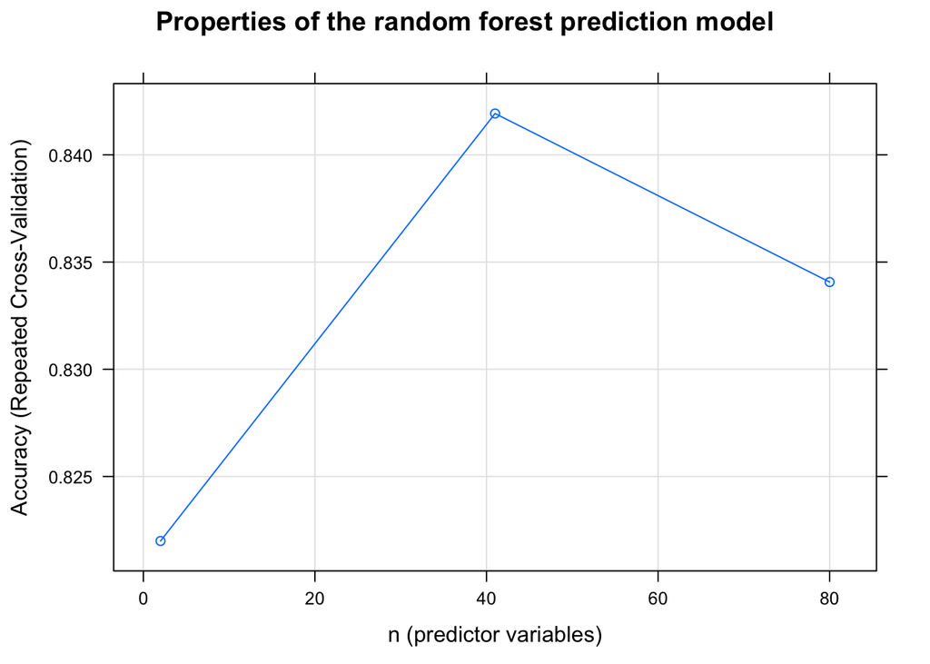

```r
plot(trainedmodel,
     main = "Properties of the random forest prediction model",
     xlab = "n (predictor variables)")
```

## 3.2 Prediction of test cases

I used the trained model to predict the outcomes of the 20 test cases.

```r
predict(trainedmodel, testing)
```

```
##  [1] A A A A A E D D A A A A B A E E A D A B
## Levels: A B C D E
```